# Microbial Compositional Analysis Along A Salinity Gradient

Mar Schmidt

April 27, 2026

# Goals

In this file, we will perform compositional analysis of our scaled/noramlized/rarefied microbial dataset!

1. Load in scaled/normalized phyloseq object.
2. Calculate the relative abundances of taxonomic groups at various levels: A. Phylum B. Genus C. ASV
3. Plot them, and narrow in on specific taxnomic group of interest
1. We will need the `scaled_physeq.RData`, which includes a rooted tree that we created in `analysis/05_Ordination/scaled_physeq.RData`.

## Outputs

# Compositional Data

Microbial abundance data—like 16S rRNA gene or metagenomics data—are typically **compositional:** they represent relative abundances constrained to a constant total (*e.g.,* percent or proportions). This introduces spurious correlations and other issues if analyzed with traditional statistics. This is a very important limitation to microbial data!

INTERPRETATION #1: What are the limitations of interpreting microbial abundance from relative (aka. compositional) rather than absolute counts?

# Setup

## Load Packages

```r
# Load in the packages
pacman::p_load(tidyverse, devtools, DT, phyloseq, patchwork,
               install = FALSE)

# load colors
source("code/colors_and_shapes.R")
```

## 1. Load in Scaled Phyloseq object

```r
load("data/Lecture/05_Ordination_Lecture/scaled_physeq.RData")

# Look at the data
scaled_physeq
```

```
## phyloseq-class experiment-level object
## otu_table()   OTU Table:         [ 2670 taxa and 88 samples ]
## sample_data() Sample Data:       [ 88 samples by 43 sample variables ]
## tax_table()   Taxonomy Table:    [ 2670 taxa by 9 taxonomic ranks ]
```

```r
# Intuition check - scaled at 1,942
min(sample_sums(scaled_physeq))
```

```
## [1] 2070
```

```r
range(sample_sums(scaled_physeq))
```

```
## [1] 2070 2133
```

# Taxonomic Analysis!

In this analysis, we will drill down from phylum to ASV level analyses, which will enable increasingly detailed insights into microbial diversity and potential ecological roles. However, it is also important for us to remember that deeper levels also come with increased noise and data sparsity, especially for rare groups.

# A. Abundant Groups: Top 10 Phyla & ASVs

## A1. Top 10 Phyla

Taxonomic analysis often begins at broader levels (*e.g.,* Phylum) to visualize overarching trends before zooming in on finer-scale patterns. This step allows us to identify which microbial groups dominate across samples and which may respond to environmental gradients like salinity.

Now, let’s calculate the relative abundance of the phyla across all the samples. **NOTE:** To do this, it is imperative that we have scaled the data to a constant sequencing depth.

```r
# Create a phylum level dataframe
phylum_df <-
  scaled_physeq %>%
  # Agglomerate all ASV counts within a phylum
  tax_glom(taxrank = "Phylum") %>%
  # Calculate the relative abundance!
  transform_sample_counts(function(x) {x/sum(x)}) %>%
  # Create a dataframe from phyloseq object
  psmelt()
  # Filter out Phyla < 1 %
  #dplyr::filter(Abundance > 0.01) %>%

## What are the phylum abundances?
phylum_df %>%
  group_by(Phylum) %>%
  summarize(mean_PercAbund = round(mean(Abundance), digits = 4)) %>%
  arrange(-mean_PercAbund) %>%
  datatable()
```

|  | Phylum | mean_PercAbund |
| --- | --- | --- |
| 1 | Cyanobacteriota | 0.3136 |
| 2 | Pseudomonadota | 0.2972 |
| 3 | Actinomycetota | 0.1496 |
| 4 | Bacteroidota | 0.1174 |
| 5 | Verrucomicrobiota | 0.0383 |
| 6 | Planctomycetota | 0.0188 |
| 7 | Bdellovibrionota | 0.0135 |
| 8 | SAR324 clade(Marine group B) | 0.0128 |
| 9 | Thermoplasmatota | 0.0086 |
| 10 | Marinimicrobia (SAR406 clade) | 0.0038 |

[output cut: 36 more lines]

```r
# Make a list of phyla the top phyla
top10_phyla <-
  phylum_df %>%
  group_by(Phylum) %>%
  summarize(mean_PercAbund = mean(Abundance)) %>%
  arrange(-mean_PercAbund) %>%
  head(n = 10) %>%
  pull(Phylum)

# show it
top10_phyla
```

```
##  [1] "Cyanobacteriota"               "Pseudomonadota"
##  [3] "Actinomycetota"                "Bacteroidota"
##  [5] "Verrucomicrobiota"             "Planctomycetota"
##  [7] "Bdellovibrionota"              "SAR324 clade(Marine group B)"
##  [9] "Thermoplasmatota"              "Marinimicrobia (SAR406 clade)"
```

INTERPRETATION #2: Which phyla in your dataset have the highest relative abundances? What are their abundances? We will focus on these phyla for plotting below. :)

**Faceted Phylum Plot**

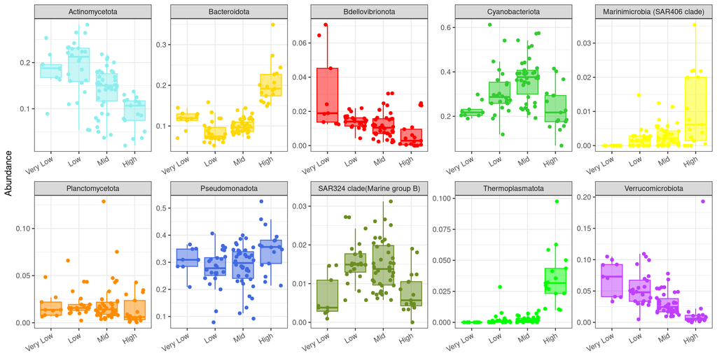

```r
### Plot the Top 10 Phyla
phylum_df %>%
  dplyr::filter(Phylum %in% top10_phyla) %>%
  ggplot(aes(x = salinity_group, y = Abundance, fill = Phylum, color = Phylum)) +
  facet_wrap(Phylum~., scales = "free", nrow = 2) +
  # add the stacked bar
  geom_jitter() +
  geom_boxplot(outlier.shape = NA, alpha = 0.5) +
  # change the colors to be our selected colors
  scale_fill_manual(values = phylum_colors) +
  scale_color_manual(values = phylum_colors) +
  theme_bw() +
  theme(legend.position = "none",
        axis.text.x = element_text(angle = 30, hjust = 1, vjust = 1),
        axis.title.x = element_blank())
```

Some specific results:

After initial exploration, we focus on specific phyla that appear to vary across stations or with salinity. These targeted plots help develop hypotheses about ecological drivers.

- Actinomycetota
- Cyanobacteriota
- Verrucomicrobiota
- Bacteroidota

INTERPRETATION #3: Make the above dotplot and boxplot for your sample types and your most abundant phyla. What *initial* conclusions can you draw regarding the sampled microbial communities as it relates to your scientific question?

Now, let’s take a look at the ASVs. This is where the *real* ecology/biology happens! This is because the ASV-level plots will provide us with a more detailed view of **which specific taxa (ASVs) are driving the overall trends seen at the higher taxonomic levels (e.g. phylum)** in relation to salinity gradients and station differences.

Before we calculate the ASV-level abundances, let’s take a second to think about *who* we’d like to consider. There’s a lot of ASVs! In fact, there are 2670! It is difficult analyze all of them! Therefore, we will remove ASVs that have an overall count across the entire dataset of 211 or 1% of a scaled sample to 2,107 This is a little arbitrary and therefore, you may choose a different threshold for your dataset. The goal here is to **dramatically decreases the number of ASVs in the dataset** to help make the ASV-level data analysis much easier.

Of course, if we had more time in class, we could run differential abundance and this would also help us to identify and statistically test which ASVs are important and also help us narrow on specific ASVs.

The goal with this lesson is to do some data exploration and then also test ASVs that are relevant for our specific study. Let’s go!

```r
# Calculate the Family relative abundance
# Note: The read depth MUST be normalized in some way: scale_reads
ASV_df <-
  scaled_physeq %>%
  # Prune out ASVs that have fewer than ~1%!
  ## LOOK AT HOW MANY ARE REMOVED! We scaled to 2,107 reads!
  prune_taxa(taxa_sums(.) >= 211, .) %>%
  # agglomerate at the phylum level
  tax_glom(taxrank = "ASV") %>%
  # Transform counts to relative abundance
  transform_sample_counts(function (x) {x/sum(x)}) %>%
  # Melt to a long format
  psmelt()


# Make a list of phyla the top 10 ASVs in the Dataset
top15_ASVs <-
  ASV_df %>%
  group_by(ASV) %>%
  summarize(mean_PercAbund = mean(Abundance)) %>%
  arrange(-mean_PercAbund) %>%
  head(n = 15) %>%
  pull(ASV)

# show it
top15_ASVs
```

```
##  [1] "ASV_0001" "ASV_0002" "ASV_0004" "ASV_0005" "ASV_0008" "ASV_0006"
##  [7] "ASV_0007" "ASV_0009" "ASV_0011" "ASV_0015" "ASV_0012" "ASV_0010"
## [13] "ASV_0016" "ASV_0014" "ASV_0025"
```

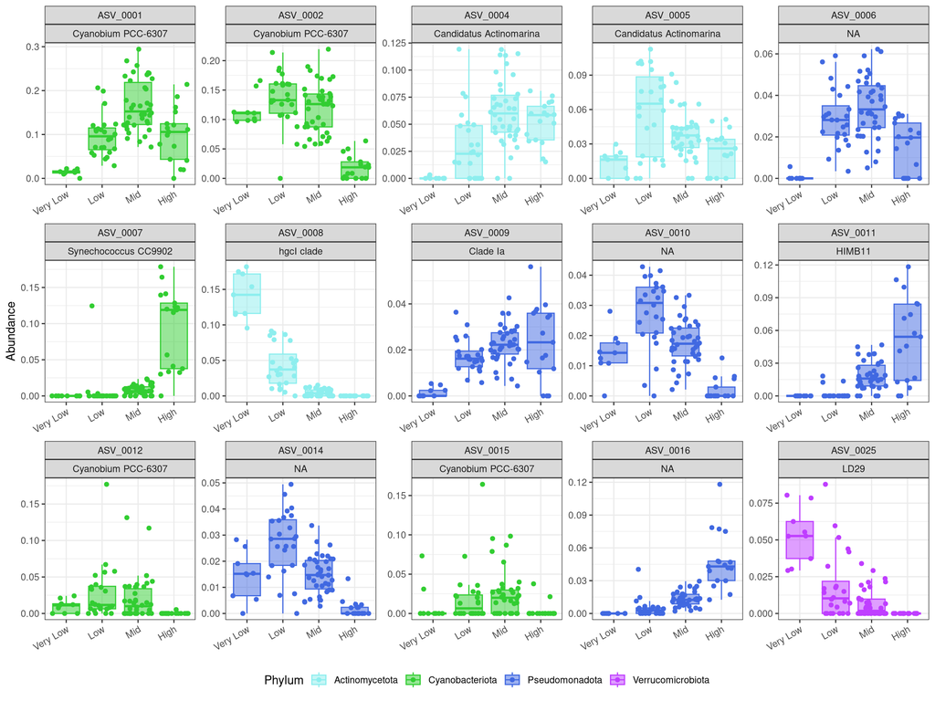

```r
### Plot the Top 10 ASVs
ASV_df %>%
  dplyr::filter(ASV %in% top15_ASVs) %>%
  ggplot(aes(x = salinity_group, y = Abundance, fill = Phylum, color = Phylum)) +
  facet_wrap(ASV~Genus, scales = "free", nrow = 3) +
  # add the stacked bar
  geom_jitter() +
  geom_boxplot(outlier.shape = NA, alpha = 0.5) +
  # change the colors to be our selected colors
  scale_fill_manual(values = phylum_colors) +
  scale_color_manual(values = phylum_colors) +
  theme_bw() +
  theme(legend.position = "bottom",
        axis.text.x = element_text(angle = 30, hjust = 1, vjust = 1),
        axis.title.x = element_blank())
```

# B. Within Phylum-Level

## B1. Actinomycetota

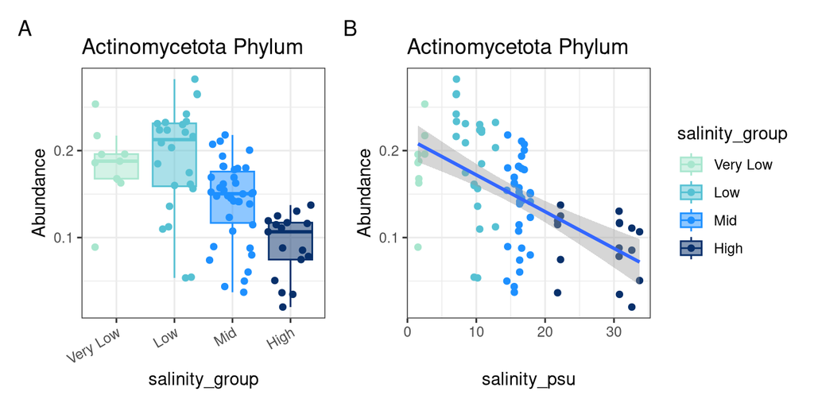

```r
# Narrow in on a specific group
# Actinomycetota - y: abundance, x: salinity_group, dot plot + boxplot
actino_phylum_salGroup <-
  phylum_df %>%
  dplyr::filter(Phylum == "Actinomycetota") %>%
  # build the plot
  ggplot(aes(x = salinity_group, y = Abundance,
             fill = salinity_group, color = salinity_group)) +
  geom_boxplot(alpha = 0.5, outlier.shape = NA) + # outliers not plotted here in boxplot
  geom_jitter() +
  theme_bw() +
  labs(title = "Actinomycetota Phylum") +
  scale_color_manual(values = salinity_colors) +
  scale_fill_manual(values = salinity_colors) +
    theme(axis.text.x = element_text(angle = 30, hjust = 1, vjust = 1),
          legend.position = "right")
# Statistically: Kruskall-Wallis followed by a Tukey's Posthoc test
# These are non-parametric (non-normal) stat tests


# CONTINUOUS
actino_phylum_salinity <-
  phylum_df %>%
  dplyr::filter(Phylum == "Actinomycetota") %>%
  ggplot(aes(x = salinity_psu, y = Abundance)) +
  geom_point(aes(color = salinity_group)) +
  theme_bw() +
  geom_smooth(method = "lm") +
  labs(title = "Actinomycetota Phylum") +
  scale_color_manual(values = salinity_colors) +
  theme(legend.position = "none")

# Collect both of the plots together into one
actino_phylum_salGroup + actino_phylum_salinity +
  plot_layout(guides = "collect") +
  plot_annotation(tag_levels = "A")
```

**Actinomycetota Abundance Across Stations and Salinity**

Actinomycetes are Gram-positive bacteria known for decomposing complex organic matter, especially in soils and freshwater systems. Their decline with increasing salinity suggests sensitivity to osmotic stress and highlights their role in freshwater nutrient cycling and carbon turnover.

## B2. Cyanobacteriota

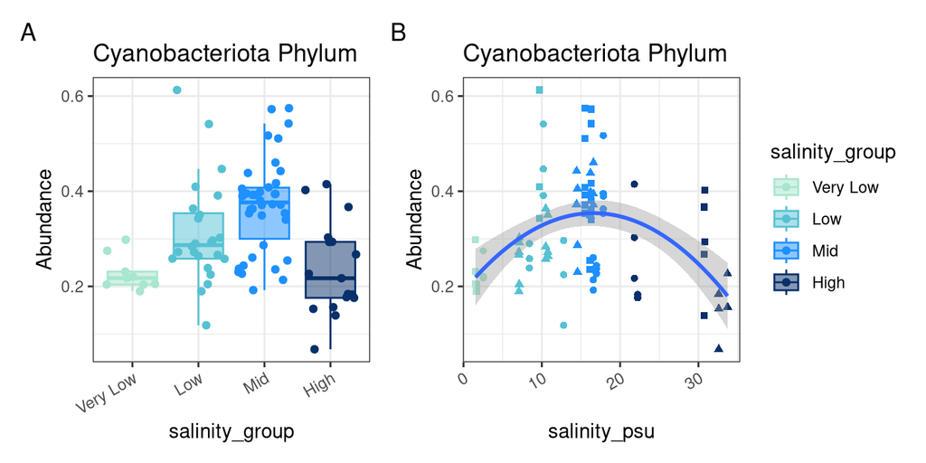

```r
# Narrow in on a specific group
# Cyanobacteriota - y: abundance, x: station, dot plot + boxplot

# Plot by salinity_group
cyano_phylum_salGroup <-
  phylum_df %>%
  dplyr::filter(Phylum == "Cyanobacteriota") %>%
  ggplot(aes(x = salinity_group, y = Abundance,
             fill = salinity_group, color = salinity_group)) +
  # outliers not plotted here in boxplot
  geom_boxplot(alpha = 0.5, outlier.shape = NA) +
  geom_jitter() +
  theme_bw() +
  labs(title = "Cyanobacteriota Phylum") +
  scale_color_manual(values = salinity_colors) +
  scale_fill_manual(values = salinity_colors) +
    theme(axis.text.x = element_text(angle = 30, hjust = 1, vjust = 1),
          legend.position = "right")
# Statistically: Kruskall-Wallis followed by a Tukey's Posthoc test
# These are non-parametric (non-normal) stat tests

# CONTINUOUS
cyano_phylum_salinity <-
  phylum_df %>%
  dplyr::filter(Phylum == "Cyanobacteriota") %>%
  # build the plot
  ggplot(aes(x = salinity_psu, y = Abundance)) +
  geom_point(aes(color = salinity_group, shape = date)) +
  theme_bw() +
  geom_smooth(method = "lm",  formula = y ~ poly(x, 2)) +
  labs(title = "Cyanobacteriota Phylum") +
  scale_color_manual(values = salinity_colors) +
  theme(axis.text.x = element_text(angle = 30, hjust = 1, vjust = 1),
          legend.position = "none")

# Collect the Cyanobacteriota Plots
cyano_phylum_salGroup + cyano_phylum_salinity +
  plot_layout(guides = "collect") +
  plot_annotation(tag_levels = "A")
```

**Cyanobacteriota Abundance Across Stations and Salinity**

A. Cyanobacteriota relative abundance varies across estuarine stations, with generally higher median abundances observed in mid-salinity environments compared to the more freshwater (Copano) and marine-influenced (Shipping Channel) sites. B. When plotted against salinity, Cyanobacteriota abundance follows a unimodal (hump-shaped) trend, peaking around intermediate salinity values (~15 PSU). This suggests that Cyanobacteriota in this system may be best adapted to brackish conditions.

Cyanobacteria are globally important primary producers, contributing significantly to oxygen production and carbon cycling. In estuaries, they often dominate in brackish waters and include both free-living and bloom-forming taxa. Their response to salinity helps indicate shifts in primary production potential and trophic dynamics.

## B3. Verrucomicrobiota

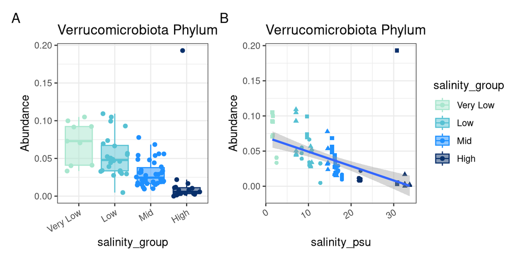

```r
# Narrow in on a specific group
# Verrucomicrobiota - y: abundance, x: station, dot plot + boxplot

# Plot by salinity_group
verruco_phylum_salGroup <-
  phylum_df %>%
  dplyr::filter(Phylum == "Verrucomicrobiota") %>%
  ggplot(aes(x = salinity_group, y = Abundance,
             fill = salinity_group, color = salinity_group)) +
  # outliers not plotted here in boxplot
  geom_boxplot(alpha = 0.5, outlier.shape = NA) +
  geom_jitter() +
  theme_bw() +
  labs(title = "Verrucomicrobiota Phylum") +
  scale_color_manual(values = salinity_colors) +
  scale_fill_manual(values = salinity_colors) +
    theme(axis.text.x = element_text(angle = 30, hjust = 1, vjust = 1),
          legend.position = "right")
# Statistically: Kruskall-Wallis followed by a Tukey's Posthoc test
# These are non-parametric (non-normal) stat tests

# CONTINUOUS
verruco_phylum_salinity <-
  phylum_df %>%
  dplyr::filter(Phylum == "Verrucomicrobiota") %>%
  ggplot(aes(x = salinity_psu, y = Abundance)) +
  geom_point(aes(color = salinity_group, shape = date)) +
  theme_bw() +
  geom_smooth(method = "lm") +
  labs(title = "Verrucomicrobiota Phylum") +
  scale_color_manual(values = salinity_colors) +
  theme(axis.text.x = element_text(angle = 30, hjust = 1, vjust = 1),
          legend.position = "none")

# Collect the Verrucomicrobiota Plots
verruco_phylum_salGroup + verruco_phylum_salinity +
  plot_layout(guides = "collect") +
  plot_annotation(tag_levels = "A")
```

**Verrucomicrobiota Abundance Across Stations and Salinity**

A. Verrucomicrobiota are most abundant in lower salinity sites (Copano West and East) and show a decreasing trend in abundance toward more saline stations (Shipping Channel). B. There is a clear negative correlation between Verrucomicrobiota abundance and salinity, suggesting this phylum may prefer fresher conditions and is less competitive in higher salinity environments.

This diverse phylum is often associated with polysaccharide degradation and has been found in soils, freshwater, and marine systems. In estuarine environments, their presence in low salinity zones suggests a role in terrestrial or freshwater organic matter processing.

## B4. Bacteroidota

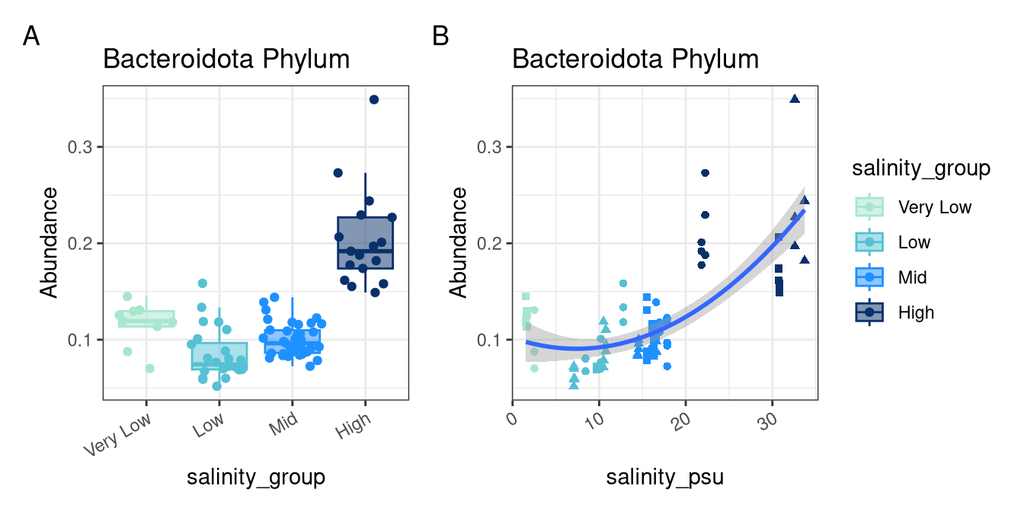

```r
# Narrow in on a specific group
# Bacteroidota - y: abundance, x: salinity_group, dot plot + boxplot

# Plot by salinity_group
bacteroidota_phylum_salGroup <-
  phylum_df %>%
  dplyr::filter(Phylum == "Bacteroidota") %>%
  ggplot(aes(x = salinity_group, y = Abundance,
             fill = salinity_group, color = salinity_group)) +
  # outliers not plotted here in boxplot
  geom_boxplot(alpha = 0.5, outlier.shape = NA) +
  geom_jitter() +
  theme_bw() +
  labs(title = "Bacteroidota Phylum") +
  scale_color_manual(values = salinity_colors) +
  scale_fill_manual(values = salinity_colors) +
    theme(axis.text.x = element_text(angle = 30, hjust = 1, vjust = 1),
          legend.position = "right")
# Statistically: Kruskall-Wallis followed by a Tukey's Posthoc test
# These are non-parametric (non-normal) stat tests

# CONTINUOUS
bacteroidota_phylum_salinity <-
  phylum_df %>%
  dplyr::filter(Phylum == "Bacteroidota") %>%
  # build the plot
  ggplot(aes(x = salinity_psu, y = Abundance)) +
  geom_point(aes(color = salinity_group, shape = date)) +
  theme_bw() +
  geom_smooth(method = "lm", formula = y ~ poly(x, 2)) +
  labs(title = "Bacteroidota Phylum") +
  scale_color_manual(values = salinity_colors) +
  theme(axis.text.x = element_text(angle = 30, hjust = 1, vjust = 1),
          legend.position = "none")

# Collect the Bacteroidota Plots
bacteroidota_phylum_salGroup + bacteroidota_phylum_salinity +
  plot_layout(guides = "collect") +
  plot_annotation(tag_levels = "A")
```

**Bacteroidota Abundance Across Stations and Salinity**

A. Unlike the other phyla, Bacteroidota relative abundance increases along the estuarine salinity gradient, with the highest levels observed in the most marine-influenced site (Shipping Channel). B. Abundance shows a strong positive correlation with salinity, indicating this phylum may be better adapted to marine or higher-salinity conditions, and potentially involved in degradation of organic matter under saline conditions.

Members of Bacteroidota are prominent degraders of high-molecular-weight organic matter such as proteins and polysaccharides. Their increasing abundance with salinity implies they may be key players in coastal and marine carbon cycling, especially in environments rich in organic particles.

## Phylum Summary

| Phylum | Salinity Trend | Peak/Preference | Interpretation |
| --- | --- | --- | --- |
| **Cyanobacteriota** | Unimodal (hump-shaped) | Brackish (~15 PSU) | Thrives in intermediate salinity; may be adapted to estuarine conditions. |
| **Actinomycetota** | Negative | Freshwater (low salinity) | Strongly freshwater-associated; declines with increasing salinity. |
| **Verrucomicrobiota** | Negative | Freshwater (low salinity) | More abundant in low-salinity environments; possibly outcompeted in saline sites. |
| **Bacteroidota** | Positive | Marine (high salinity) | Increases with salinity; likely involved in marine organic matter degradation. |

INTERPRETATION #4: Based on these phylum-level analyses, were there any phyla that you were able to identify to focus on moving forward for deeper taxonomic analyses? Why?

# C. Genus-Level

Let’s first calculate the genus data frame.

```r
# Calculate the Family relative abundance
# Note: The read depth MUST be normalized in some way: scale_reads
genus_df <-
  scaled_physeq %>%
  # agglomerate at the phylum level
  tax_glom(taxrank = "Genus") %>%
  # Transform counts to relative abundance
  transform_sample_counts(function (x) {x/sum(x)}) %>%
  # Melt to a long format
  psmelt()
```

## C1. Actinomycetota Genera

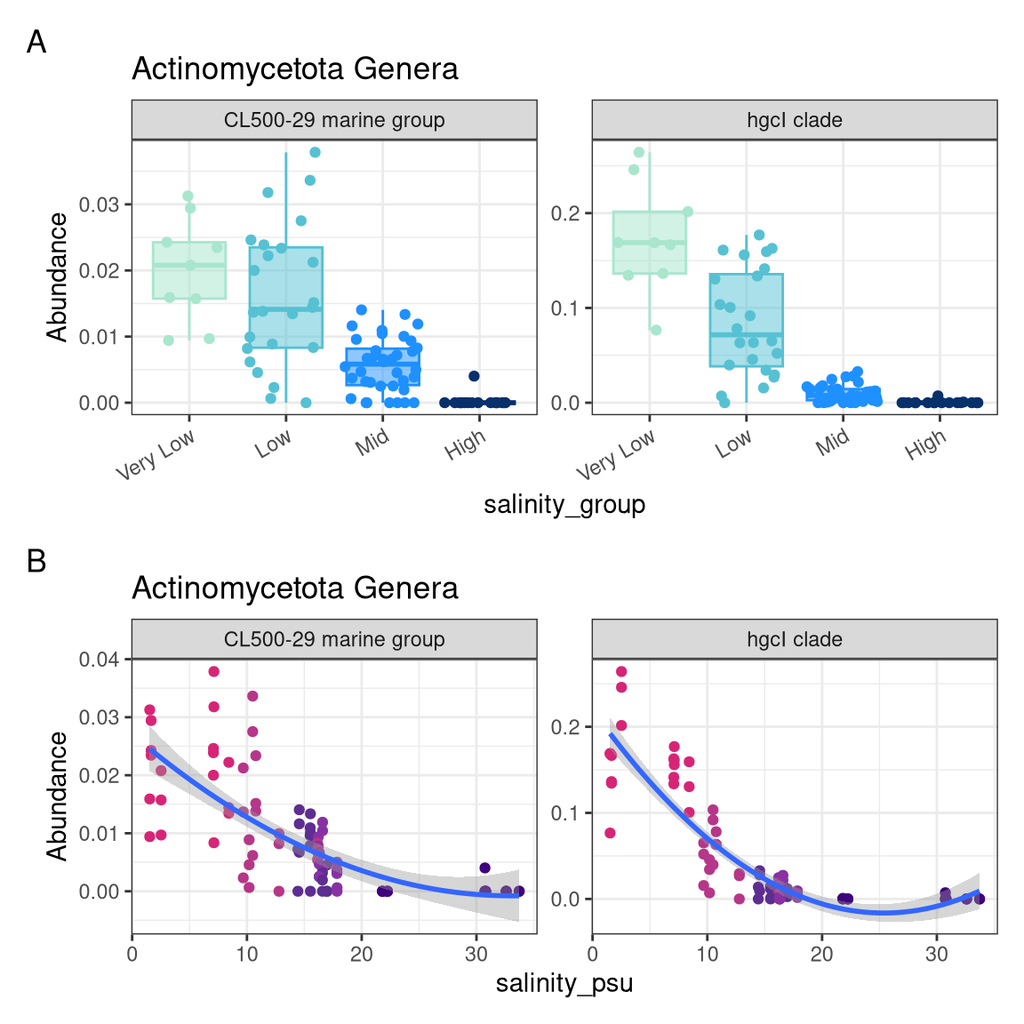

```r
# Actinobacteriota
# Plot genus
actino_genus_salGroup <-
  genus_df %>%
  dplyr::filter(Phylum == "Actinomycetota") %>%
  # At first, plot all of the genera and then subset the ones that have intersting trends
  dplyr::filter(Genus %in% c("hgcI clade", "CL500-29 marine group")) %>%
  # build the plot
  ggplot(aes(x = salinity_group, y = Abundance,
             fill = salinity_group, color = salinity_group)) +
  facet_wrap(.~Genus, scales = "free_y", nrow = 1) +
  geom_boxplot(alpha = 0.5, outlier.shape = NA) + # outliers not plotted here in boxplot
  geom_jitter() +
  theme_bw() +
  labs(title = "Actinomycetota Genera") +
  scale_color_manual(values = salinity_colors) +
  scale_fill_manual(values = salinity_colors) +
  theme(axis.text.x = element_text(angle = 30, hjust = 1, vjust = 1),
        legend.position = "none")

# Plot genus: Continuous
actino_genus_salinity <-
  genus_df %>%
  dplyr::filter(Phylum == "Actinomycetota") %>%
  dplyr::filter(Genus %in% c("hgcI clade", "CL500-29 marine group")) %>%
  # build the plot
  ggplot(aes(x = salinity_psu, y = Abundance)) +
  facet_wrap(.~Genus, scales = "free_y", nrow = 1) +
  geom_point(aes(color = station)) +  theme_bw() +
  geom_smooth(method = "lm",  formula = y ~ poly(x, 2)) +
  labs(title = "Actinomycetota Genera") +
  scale_color_manual(values = station_colors) +
  theme(legend.position = "none")

# Collect the Actinomycetota Plots
actino_genus_salGroup / actino_genus_salinity +
  plot_layout(guides = "collect") +
  plot_annotation(tag_levels = "A")
```

**Genera-Level Response of Actinomycetota to Station and Salinity**

This figure shows the relative abundance of two dominant Actinomycetota genera—CL500-29 marine group and hgcI clade—across salinity groups (A) and a salinity gradient (B).

1. **CL500-29 marine group** exhibits a moderate negative correlation with salinity. While present across all stations, its abundance is highest at low-salinity sites (Copano West and East) and gradually decreases toward marine-influenced sites. This suggests it may be a freshwater-to-brackish adapted taxon, sensitive to higher salinities.
2. **hgcI clade** shows a steep decline in abundance with increasing salinity, with high relative abundance in low-salinity stations and almost complete absence beyond 15 PSU. This genus appears to be a strong freshwater specialist, intolerant of salinity increases, making it a potential bioindicator of freshwater influence in estuarine systems. *However, note the highly variable abundances at lower salinity. We need to be mindful of the stats here!*

These patterns reinforce the role of salinity as a key environmental filter in structuring Actinomycetota populations and suggest functional or physiological constraints that limit these genera to distinct salinity niches.

## C2. Cyanobacteriota Genera

Let’s take a look at two important and very abundant Cyano Genera:

1. **Cyanobium PCC-6307**
   - Widespread in freshwater and brackish systems, including lakes, estuaries, and rivers.
   - Small, unicellular, coccoid
   - Typically contain phycocyanin (not phycoerythrin), giving them a bluish-green color
2. **Synechococcus CC9902**:
   - Rod-shaped or coccoid, ~1 µm
   - Contains phycoerythrin (orange-pink color), adapted to absorb blue-green light in the open ocean
   - Synechococcus is among the most abundant photoautotrophs in the ocean, contributing up to 10–20% of marine primary production.
   - CC9902 is frequently used as a model for:
   - Population structure and ecotype
   - Viral-host interactions (cyanophages)
   - Adaptive evolution in picocyanobacteria

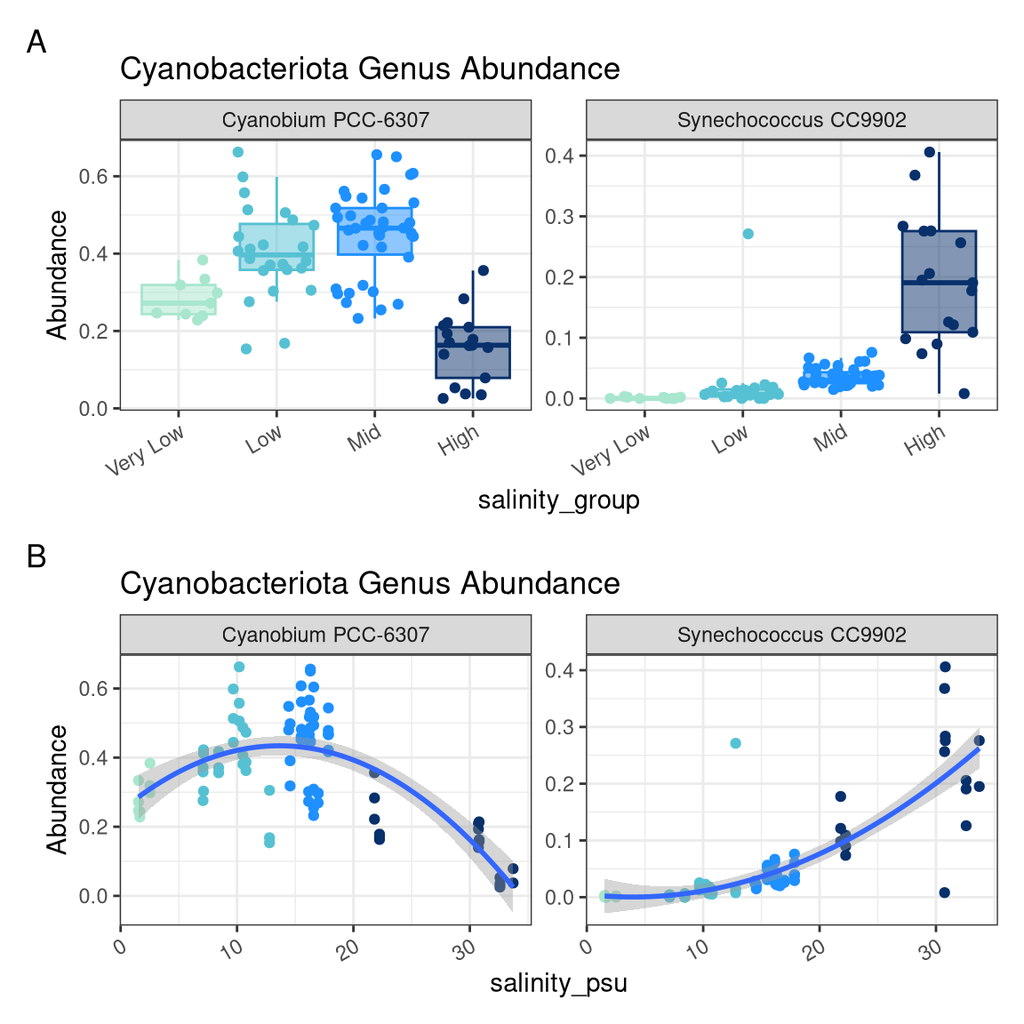

```r
# Plot genus: Categorical
cyano_genus_salGroup <-
  genus_df %>%
  dplyr::filter(Phylum == "Cyanobacteriota") %>%
  dplyr::filter(Genus %in% c("Cyanobium PCC-6307", "Synechococcus CC9902")) %>%
  # build the plot
  ggplot(aes(x = salinity_group, y = Abundance,
             fill = salinity_group, color = salinity_group)) +
  facet_wrap(.~Genus, scales = "free_y", nrow = 1) +
  geom_boxplot(alpha = 0.5, outlier.shape = NA) + # outliers not plotted here in boxplot
  geom_jitter() +
  theme_bw() +
  labs(title = "Cyanobacteriota Genus Abundance") +
  scale_color_manual(values = salinity_colors) +
  scale_fill_manual(values = salinity_colors) +
  theme(axis.text.x = element_text(angle = 30, hjust = 1, vjust = 1),
        legend.position = "none")

# Plot genus: Continuous
cyano_genus_salinity <-
  genus_df %>%
  dplyr::filter(Phylum == "Cyanobacteriota") %>%
  dplyr::filter(Genus %in% c("Cyanobium PCC-6307", "Synechococcus CC9902")) %>%
  # build the plot
  ggplot(aes(x = salinity_psu, y = Abundance)) +
  facet_wrap(.~Genus, scales = "free_y", nrow = 1) +
  geom_point(aes(color = salinity_group)) +  theme_bw() +
  geom_smooth(method = "lm",  formula = y ~ poly(x, 2)) +
  labs(title = "Cyanobacteriota Genus Abundance") +
  scale_color_manual(values = salinity_colors) +
  theme(axis.text.x = element_text(angle = 30, hjust = 1, vjust = 1),
        legend.position = "none")

# Collect the Cyanobacteriota Plots
cyano_genus_salGroup / cyano_genus_salinity +
  plot_layout(guides = "collect") +
  plot_annotation(tag_levels = "A")
```

**Genus-Level Response of Cyanobacteriota to Salinity**

The above figure displays how two cyanobacterial genera—Cyanobium PCC-6307 and Synechococcus CC9902—respond to a continuous salinity gradient across estuarine environments. We can conclude that:

1. **Cyanobium PCC-6307** shows a clear unimodal response, peaking at intermediate salinities (~15 PSU). This genus is abundant in brackish waters, indicating it may be well-adapted to estuarine mixing zones where freshwater and marine influences converge. Its decline at both low and high salinities suggests physiological limits at environmental extremes.
2. **Synechococcus CC9902** shows a strong positive relationship with salinity, with relative abundance increasing sharply in higher-salinity waters. This pattern is consistent with its role as a marine-adapted picocyanobacterium, commonly found in open ocean environments. Its abundance in high-salinity sites highlights niche differentiation between freshwater/brackish and marine cyanobacterial clades. However, it’s important to note that there is a large amount of variability in the most saline samples.

Together, these patterns illustrate niche partitioning within Cyanobacteriota along environmental gradients and emphasize how salinity acts as a strong ecological filter shaping microbial community composition at fine taxonomic resolution.

INTERPRETATION #5: Please make some plots of mid-level taxonomic ranks (e.g. Genus, Family, Order) as it relates to your scientific question. Were there any changes in the mid-level taxonomic trends compared to the phylum-level results? What does that tell you about that taxonomic group?

# D. ASV-Level

## D1. Actinomycetota ASVs

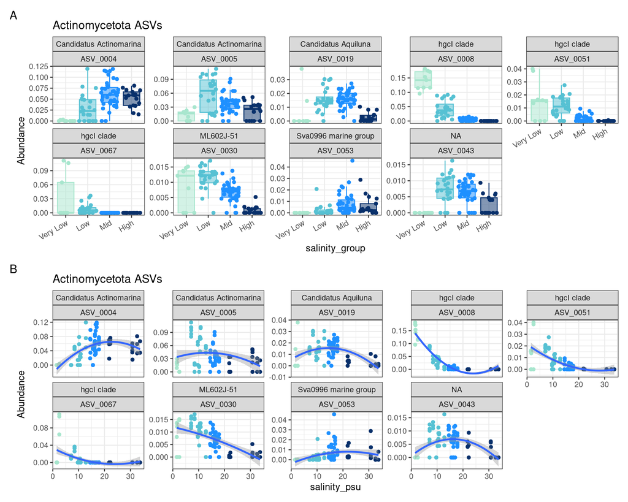

```r
# Calculate top couple of ASVs
# Make a list of phyla the top phyla
top_actino_ASVs <-
  ASV_df %>%
  dplyr::filter(Phylum == "Actinomycetota") %>%
  group_by(ASV) %>%
  summarize(mean_Abundance = mean(Abundance)) %>%
  dplyr::filter(mean_Abundance > 0.005) %>%
  pull(ASV)

# Actinobacteriota
# Plot ASVs
actino_asv_salGroup <-
  ASV_df %>%
  dplyr::filter(ASV %in% top_actino_ASVs) %>%
  # build the plot
  ggplot(aes(x = salinity_group, y = Abundance,
             fill = salinity_group, color = salinity_group)) +
  facet_wrap(Genus~ASV, scales = "free_y", nrow = 2) +
  geom_boxplot(alpha = 0.5, outlier.shape = NA) + # outliers not plotted here in boxplot
  geom_jitter() +
  theme_bw() +
  labs(title = "Actinomycetota ASVs") +
  scale_color_manual(values = salinity_colors) +
  scale_fill_manual(values = salinity_colors) +
  theme(axis.text.x = element_text(angle = 30, hjust = 1, vjust = 1),
        legend.position = "none")

# Plot ASVs: Continuous
actino_asv_salinity <-
  ASV_df %>%
  dplyr::filter(ASV %in% top_actino_ASVs) %>%
  # build the plot
  ggplot(aes(x = salinity_psu, y = Abundance)) +
  facet_wrap(Genus~ASV, scales = "free_y", nrow = 2) +
  geom_point(aes(color = salinity_group)) +  theme_bw() +
  geom_smooth(method = "lm",  formula = y ~ poly(x, 2)) +
  labs(title = "Actinomycetota ASVs") +
  scale_color_manual(values = salinity_colors) +
  theme(legend.position = "none")

# Collect the Actinomycetota Plots
actino_asv_salGroup / actino_asv_salinity +
  plot_layout(guides = "collect") +
  plot_annotation(tag_levels = "A")
```

A. **Relationship to Salinity Group:**

B. **Relationship to Salinity:**

## D2. Cyanobacterial ASVs

Let’s narrow in on more abundant ASVs by removing any ASVs that are less than 0.5% abundance. Otherwise there were many ASVs in this group!

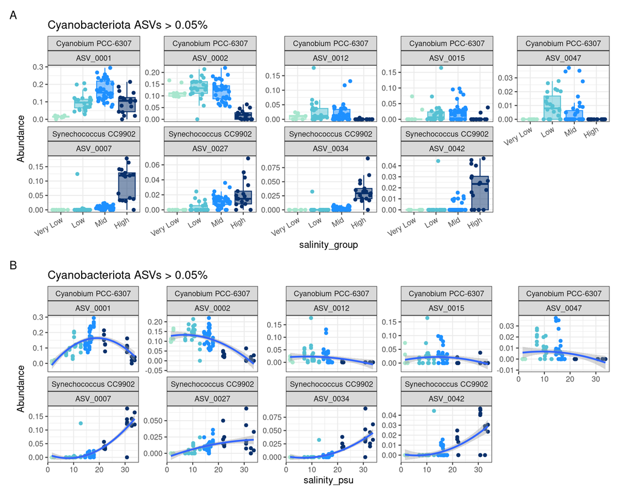

```r
# Calculate top couple of ASVs
# Make a list of phyla the top phyla
top_cyano_ASVs <-
  ASV_df %>%
  dplyr::filter(Phylum == "Cyanobacteriota") %>%
  group_by(ASV) %>%
  summarize(mean_Abundance = mean(Abundance)) %>%
  dplyr::filter(mean_Abundance > 0.005) %>%
  pull(ASV)

# Plot ASVs: Salinity Group
cyano_asv_salGroup <-
  ASV_df %>%
  # Subset for more abundant ASVs
  dplyr::filter(ASV %in% top_cyano_ASVs) %>%
  # build the plot
  ggplot(aes(x = salinity_group, y = Abundance,
             fill = salinity_group, color = salinity_group)) +
  facet_wrap(Genus~ASV, scales = "free_y", nrow = 2) +
  geom_boxplot(alpha = 0.5, outlier.shape = NA) + # outliers not plotted here in boxplot
  geom_jitter() +
  theme_bw() +
  labs(title = "Cyanobacteriota ASVs > 0.05%") +
  scale_color_manual(values = salinity_colors) +
  scale_fill_manual(values = salinity_colors) +
  theme(axis.text.x = element_text(angle = 30, hjust = 1, vjust = 1),
        legend.position = "none")

# Plot ASVs: Continuous
cyano_asv_salinity <-
  ASV_df %>%
  dplyr::filter(ASV %in% top_cyano_ASVs) %>%
  # build the plot
  ggplot(aes(x = salinity_psu, y = Abundance)) +
  facet_wrap(Genus~ASV, scales = "free_y", nrow = 2) +
  geom_point(aes(color = salinity_group)) +  theme_bw() +
  geom_smooth(method = "lm",  formula = y ~ poly(x, 2)) +
  labs(title = "Cyanobacteriota ASVs > 0.05%") +
  scale_color_manual(values = salinity_colors) +
  theme(legend.position = "none")

# Collect the Actinomycetota Plots
cyano_asv_salGroup / cyano_asv_salinity +
  plot_layout(guides = "collect") +
  plot_annotation(tag_levels = "A")
```

Ok, this is interesting! While the phylum-level plot shows a clear unimodal relationship with salinity, the ASV-level analysis reveals taxon-specific responses, with Cyanobium peaking at moderate salinity and Synechococcus increasing with high salinity. This suggests differential adaptation strategies and niche differentiation within Cyanobacteriota in response to salinity gradients.

A. **Relationship to Salinity Group:** This spatial pattern reinforces the environmental filtering hypothesis, where salinity selects for different cyanobacterial taxa. In the samples with the highest salinity, a spike in Synechococcus ASVs and a concomitant decline or absence of many Cyanobium ASVs. However, samples with lower salinities are dominated by Cyanobium ASVs.

INTERPRETATION #6: Were the most abundant ASVs in your dataset represented in your ASV-level plots? If not, please go back and plot them specifically. (Hint: Remember that we ordered our ASV names by abundance across the entire dataset. Therefore, ASV_0001 will be the most abundant, ASV_0007 will be the 7th most abundant and so on.)

INTERPRETATION #7: Please make some plots at the ASV level as it relates to your scientific question. Were there any ASVs that were especially related to trends that you saw? Did a specific phylogenetic group all show the same trends (e.g. like the Actinomycetota ASVs above)? Or did the ASVs have various, likely niche-specific responses (similar to the Cyanobacteriota above)??

INTERPRETATION #8: Now, do a quick literature or google search and look back in the paper that you may be replicating (if applicable). Does your ASV-level changes represent something that is currently known? Or is this a novel result? What did you learn about this ASV or a group of ASVs in your dataset?

## D3. Verrucomicrobiota

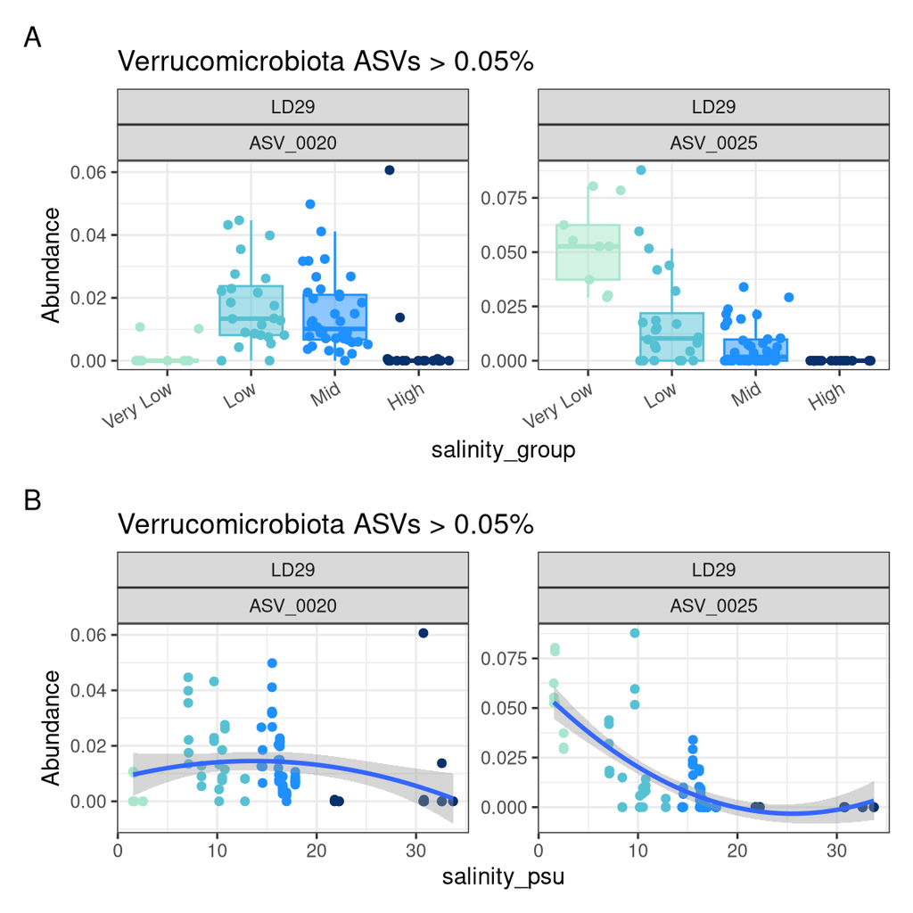

```r
# Calculate top couple of ASVs
# Make a list of phyla the top phyla
top_verruco_ASVs <-
  ASV_df %>%
  dplyr::filter(Phylum == "Verrucomicrobiota") %>%
  group_by(ASV) %>%
  summarize(mean_Abundance = mean(Abundance)) %>%
  dplyr::filter(mean_Abundance > 0.005) %>%
  pull(ASV)

# Plot ASVs: Station
verruco_asv_salGroup <-
  ASV_df %>%
  # Subset for more abundant ASVs
  dplyr::filter(ASV %in% top_verruco_ASVs) %>%
  # build the plot
  ggplot(aes(x = salinity_group, y = Abundance,
             fill = salinity_group, color = salinity_group)) +
  facet_wrap(Genus~ASV, scales = "free_y", nrow = 1) +
  geom_boxplot(alpha = 0.5, outlier.shape = NA) + # outliers not plotted here in boxplot
  geom_jitter() +
  theme_bw() +
  labs(title = "Verrucomicrobiota ASVs > 0.05%") +
  scale_color_manual(values = salinity_colors) +
  scale_fill_manual(values = salinity_colors) +
  theme(axis.text.x = element_text(angle = 30, hjust = 1, vjust = 1),
        legend.position = "none")

# Plot ASVs: Continuous
verruco_asv_salinity <-
  ASV_df %>%
  dplyr::filter(ASV %in% top_verruco_ASVs) %>%
  # build the plot
  ggplot(aes(x = salinity_psu, y = Abundance)) +
  facet_wrap(Genus~ASV, scales = "free_y", nrow = 1) +
  geom_point(aes(color = salinity_group)) +  theme_bw() +
  geom_smooth(method = "lm",  formula = y ~ poly(x, 2)) +
  labs(title = "Verrucomicrobiota ASVs > 0.05%") +
  scale_color_manual(values = salinity_colors) +
  theme(legend.position = "none")

# Collect the Actinomycetota Plots
verruco_asv_salGroup / verruco_asv_salinity +
  plot_layout(guides = "collect") +
  plot_annotation(tag_levels = "A")
```

## D4. Bacteroidota

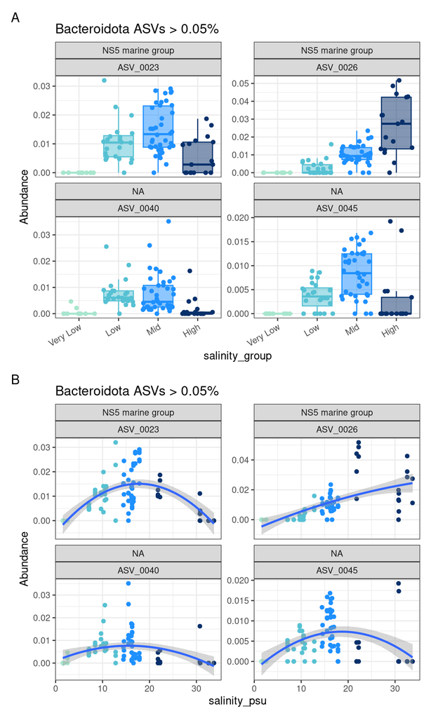

```r
# Calculate top couple of ASVs
# Make a list of phyla the top phyla
top_bacter_ASVs <-
  ASV_df %>%
  dplyr::filter(Phylum == "Bacteroidota") %>%
  group_by(ASV) %>%
  summarize(mean_Abundance = mean(Abundance)) %>%
  dplyr::filter(mean_Abundance > 0.005) %>%
  pull(ASV)

# Plot ASVs: salinity_group
bacter_asv_salGroup <-
  ASV_df %>%
  # Subset for more abundant ASVs
  dplyr::filter(ASV %in% top_bacter_ASVs) %>%
  # build the plot
  ggplot(aes(x = salinity_group, y = Abundance,
             fill = salinity_group, color = salinity_group)) +
  facet_wrap(Genus~ASV, scales = "free_y", nrow = 2) +
  geom_boxplot(alpha = 0.5, outlier.shape = NA) + # outliers not plotted here in boxplot
  geom_jitter() +
  theme_bw() +
  labs(title = "Bacteroidota ASVs > 0.05%") +
  scale_color_manual(values = salinity_colors) +
  scale_fill_manual(values = salinity_colors) +
  theme(axis.text.x = element_text(angle = 30, hjust = 1, vjust = 1),
        legend.position = "none")

# Plot ASVs: Continuous
bacter_asv_salinity <-
  ASV_df %>%
  dplyr::filter(ASV %in% top_bacter_ASVs) %>%
  # build the plot
  ggplot(aes(x = salinity_psu, y = Abundance)) +
  facet_wrap(Genus~ASV, scales = "free_y", nrow = 2) +
  geom_point(aes(color = salinity_group)) +  theme_bw() +
  geom_smooth(method = "lm",  formula = y ~ poly(x, 2)) +
  labs(title = "Bacteroidota ASVs > 0.05%") +
  scale_color_manual(values = salinity_colors) +
  theme(legend.position = "none")

# Collect the Actinomycetota Plots
bacter_asv_salGroup / bacter_asv_salinity +
  plot_layout(guides = "collect") +
  plot_annotation(tag_levels = "A")
```